# Introducción a la estadística descriptiva

Carlos J. Gil Bellosta

2017-10-31

# Decisiones y teoría de la decisión

## Algunas decisiones simples

- ¿Qué calcetines me pongo?
- Está lloviendo: ¿cojo el paraguas?
- En el supermercado: ¿fideos de marca A o de marca B?

## Otro tipo de decisiones

- No está nublado pero dicen que igual llueve: ¿cojo el paraguas?
- Tengo una entrevista: ¿traje o sport?
- ¿Compro acciones de Caixabank ahora que…?

## Determinismo vs incertidumbre

- Las primeras decisiones son *casi* deterministas: si X entonces Y
- Las segundas involucran *un algo* aleatorio (*contingencias*)

## Decisiones bajo incertidumbre: escenarios y recompensas

- La teoría de la decisión está basada en *escenarios*
- Cada escenario tiene una *recompensa* asociada
- Hay varios criterios para recomponer la recompensa de una decisión *a través de todos los posibles escenarios*
- En el fondo, existe la necesidad de **comparar** escenarios.

> Recuerda este verbo: **comparar**.

## Ejemplo

- Trabajas una empresa y tienes la opción de hacer algo:
  - Si no lo haces, no pasa nada
  - Si lo haces y lo haces bien, no tendrás premio
  - Si lo haces y lo haces mal, tendrás un castigo
- ¿Qué haces?

## Una variante del ejemplo anterior

- Trabajas una empresa y tienes la opción de hacer algo:
  - Si no lo haces, no pasa nada
  - Si lo haces y lo haces bien, tendrás un premio
  - Si lo haces y lo haces mal, tendrás un castigo
- ¿Qué haces?

> Comienza a hacerse evidente la necesidad de asignar *pesos* (¿*perspectivas de viabilidad*?) a los escenarios.

## El problema del vendedor de periódicos

- Está [descrito en la Wikipedia](https://en.wikipedia.org/wiki/Newsvendor_model)
- Esencialmente: un intermediario tiene que decidir cuántos periódicos comprar para revenderlos
- Decisión *óptima* (según cierto criterio):

$$q = F^{-1}\left(\frac{p-c}{p} \right)$$

## La importancia de ponderar los escenarios

Nos la va a explicar [Iñaki Gabilondo](https://elpais.com/elpais/2017/10/31/la_voz_de_inaki/1509437310_484584.html).

# Escenarios y probabilidades

## De nuevo, un vídeo

[Este](https://www.youtube.com/watch?v=6YDHBFVIvIs)

## Glosario

- **Escenarios (o *eventos*):** sucesos contingentes, que pueden ocurrir o no.
- **Frecuencias:** número de ocurrencias de cada escenario en un *experimento* con $n$ repeticiones.
- **Histograma:** una representación gráfica de las frecuencias.
- **Distribución de probabilidad:** *forma teórica* a la que *tiende* el histograma tras muchas repeticiones.

## La frecuencia tiende a la distribución

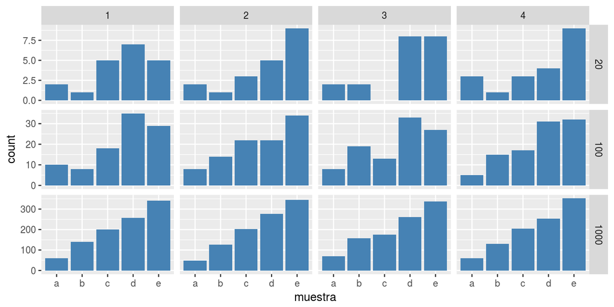

## Notas

- Estamos representando los conteos
- A más observaciones, más similares son los perfiles de los *histogramas*.
- (Nota: en realidad no son *histogramas* propiamente dichos, pero abusaré del lenguaje)
- Podemos pasar a proporciones

## Con proporciones

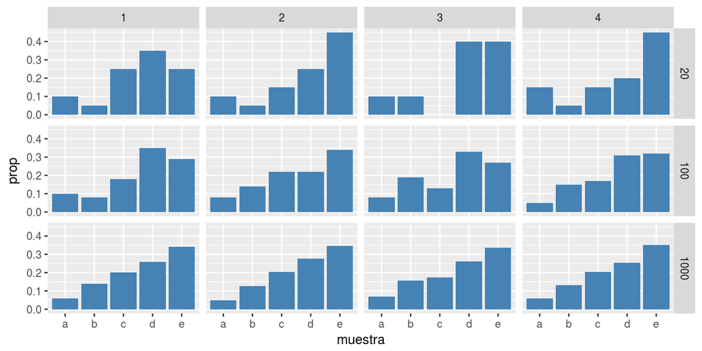

## Notas:

- El perfil de los gráficos es el mismo que con frecuencias.
- Pero ahora la suma de las alturas de las barras es 1.
- Cada barra aproxima la *probabilidad* de cada evento.
- ¡Cuidado cuando hay pocas observaciones!
- En particular, ten cuidado con las **comparaciones** cuando hay pocas observaciones.

## Con distribuciones continuas

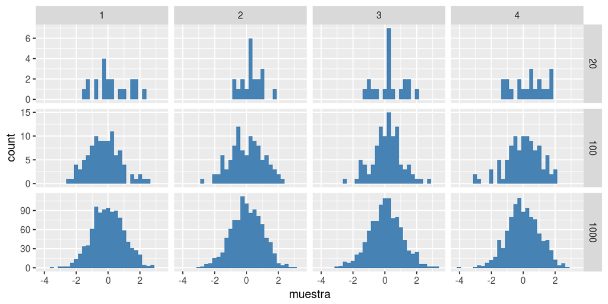

## Densidades (normales)

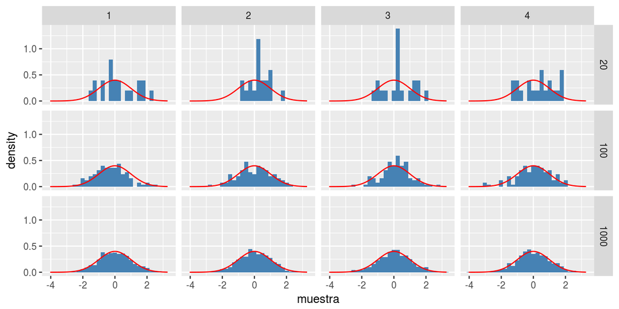

## Densidades (gamma)

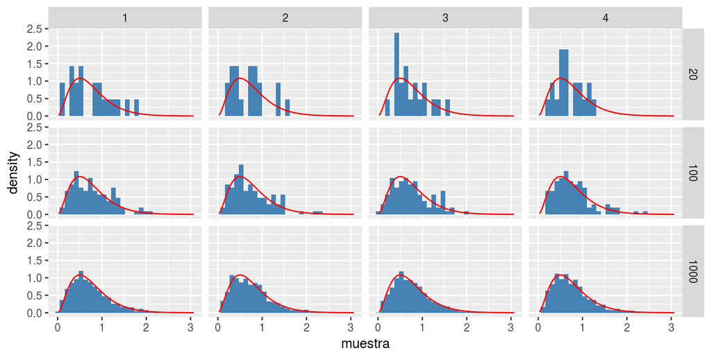

# Teoría de la probabilidad

## Eventos

- Un evento es algo que puede ocurrir o no ocurir (¡un escenario!):
  - X en la quiniela
  - Que la bolsa suba un 5% antes de fin de año
  - Que haya atasco en la M30
  - …
- Con los eventos se opera como con conjuntos: unión, intersección, etc.
  - 1 o X en la quiniela (unión)
  - Que no llueva pero que haya atasco en la M30 (intersección)

## Probabilidades

- La probabilidad es
  - un número (entre 0 y 1 o como porcentaje)
  - que se asigna a eventos
  - de acuerdo con ciertas reglas (que no trataremos)
- Mide nuestro grado de certeza
- Hay muchas maneras de asignar probabilidades a eventos:
  - Objetivas: dados, cartas, qunincunces, etc.
  - Subjetivas: ¿quién ganará las elecciones?

## El caso de Linda

*Linda is thirty-one years old, single, outspoken, and very bright. She majored in philosophy. As a student, she was deeply concerned with issues of discrimination and social justice, and also participated in anti-nuclear demonstrations…*

The respondents are asked to rank in order of likelihood various scenarios: Linda is

1. an elementary school teacher,
2. active in the feminist movement,
3. a bank teller,
4. an insurance salesperson, or
5. a bank teller also active in the feminist movement.

## Estadística y probabilidad

- En probabilidad las probabilidades de los eventos son conocidas
- La estadística trata de asignar probabilidades a eventos (a partir de datos observados)

## Variables aleatorias

- Una variable aleatoria es una función que *genera eventos*
- Suelen representarse con mayúsculas ($X$, $Y$, etc.)
- Casi siempre vamos a fijarnos en eventos *generados* por variables aleatorias
- Ejemplos:
  - Variable aleatoria: $X$ es la suma los puntos en una tirada de cuatro dados
  - Evento: que $X$ sea mayor que 12
  - Variable aleatoria: $X$ es el número de periódicos vendidos en Zaragoza
  - Evento: que $X$ sea inferior a 10000

## Tipos de variables aleatorias

- **Categóricas:** 1-X-2 como en las quinielas, hombre/mujer, etc.
- **Ordenadas:** bueno/regular/malo, etc.
- **Enteras:** número de accidentes de tráfico, número de ejemplares vendidos, etc.
- **Continuas:** peso de un sujeto, velocidad de un vehículo, variación en el precio de una acción, etc.

# Estadística descriptiva

## Objetivo

- Tomar mejores decisiones
- Para lo que hace falta:
  - Escenarios bien *calibrados* (¡recordemos a Iñaki!)
  - Conocer y describir las variables aleatorias involucradas
  - Para lo que hace falta poder **comparar** escenarios
- Nos centraremos en los aspectos cualitativos y gráficos

# Estadística descriptiva: variables aleatorias categóricas

## Variables aleatorias categóricas

- Toman valores categóricos:
  - **binarios:** dos categorías, e.g.: hombre/mujer
  - **en general:** provincias, códigos postales, colores,…
  - **ordenadas:** bueno/regular/malo, etc.
- Lo interesante: describir su *distribución*, i.e., la probabilidad de cada categoría.

## Descripción de variables aleatorias categóricas

- La manera canónica es mediante el *histograma*
- Técnicamente, un diagrama de barras
- Técnicas alternativas:
  - tablas ([algunos consejos](https://gss.civilservice.gov.uk/wp-content/uploads/2017/01/GUIDANCE-document-Effective-charts-and-tables-in-official-statistics-Version-2.0-Jan2017.pdf))
  - diagramas de puntos
  - tartas
  - otras más o menos artísticas

## Representaciones gráficas: barras

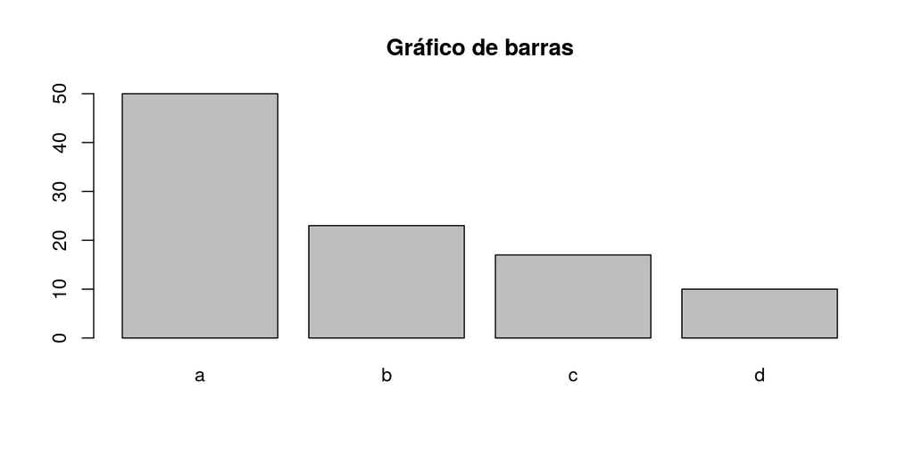

## Representaciones gráficas: puntos

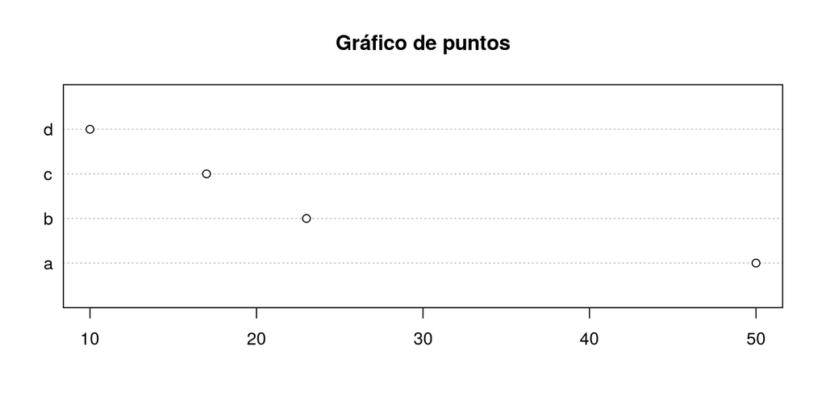

## Representaciones gráficas: tartas

- Tratan de representar categorías como parte de un todo
- [No se recomiendan](https://www.datanalytics.com/2011/03/02/1658/)
- El motivo (bien estudiado por la sicología) tiene que ver con la teoría de la percepción:
  - El ojo percibe bien longitudes
  - Pero ángulos o áreas no
  - Mucho menos, representaciones gráficas de volúmenes
- En resumen: no tartas, no efectos 3D, no perspectivas

## Otras representaciones artísticas

- *Pictogramas* como [este](http://topdrawer.aamt.edu.au/var/aamt/storage/images/media/tdt/statistics/s_a_ap1_s2_fig1/283871-1-eng-AU/S_A_AP1_S2_fig1.png)
- *Ideogramas* como los de [esta infografía](http://biovis.net/2016/files/stolte-matrix-solution.png)
- *Treemaps* como [este](https://www.infragistics.com/samples/WebImages/WPF/Controls/xamTreemap/WPF-treemap-value-mapping-key-features-image-dv.jpg), que pueden ser útiles para representar datos por provincia, código postal, etc.

## Conteos y frecuencias

- Las frecuencias relativas se aproximan a las probabilidades…
- … con un error que decrece conforme más *experimentos* se realicen
- Ej.: ¿Qué significa 100? ¡Depende del número de ensayos!
- Ej.: [eficacia de los porteros en la liga](http://www.20minutos.es/deportes/estadisticas/liga/player_leaders.asp?category=107)
- Es importante tener en cuenta los [*intervalos de confianza*](http://sites.stat.psu.edu/~ajw13/stat500_su_res/notes/lesson06/images/con_int1.gif) (que no vamos a tratar)

## Precisión e incertidumbre

- Hay muchas maneras de expresar *incertidumbre* en probabilidades y proporciones
- Una de ellas es mediante la precisión (por ejemplo, [en AEMET](http://www.aemet.es/es/eltiempo/prediccion/municipios/madrid-id28079))
- Otro ejemplo con [porteros de la liga de fútbol](https://www.datanalytics.com/2015/07/15/un-modelo-jerarquico-para-lo-de-casillas/)

# Estadística descriptiva: variables aleatorias continuas

## Variables aleatorias continuas

- Toman valores numéricos: e.g., pesos, alturas, ingresos, etc. de personas
- Frecuentemente se distingue entre continuas (p.e., pesos) y discretas (p.e., número de accidentes)
- Lo interesante, de nuevo: describir su *distribución*.
- Como hemos visto, la descripción canónica es el *histograma*.

## Problemas del histograma

- Exige tener delante una pantalla, un papel impreso, un…
- Otros son históricos: *antes* era difícil construirlos y distribuirlos
- Existen descripciones *simplificadas* de distribuciones de probabilidad:
  - Medidas de centralidad
  - Medidas de dispersión
  - …

## Medidas de centralidad

- Responden a la pregunta: ¿cuál es el valor promedio o típico o esperado…?
- P.e.: *una botella de vino viene a costar 8 euros* (¿es una información *suficiente*?)
- (¿Tiene siempre sentido la pregunta anterior?)
- Medidas de centralidad habituales:
  - **Media:** suma del valor de las obs. dividido por su número
  - **Mediana:** aquel valor que está en medio, i.e., que deja al 50% por encima y el 50% por debajo
  - **Moda:** el valor más frecuente

## Gráficamente (normal, pocas obs.)

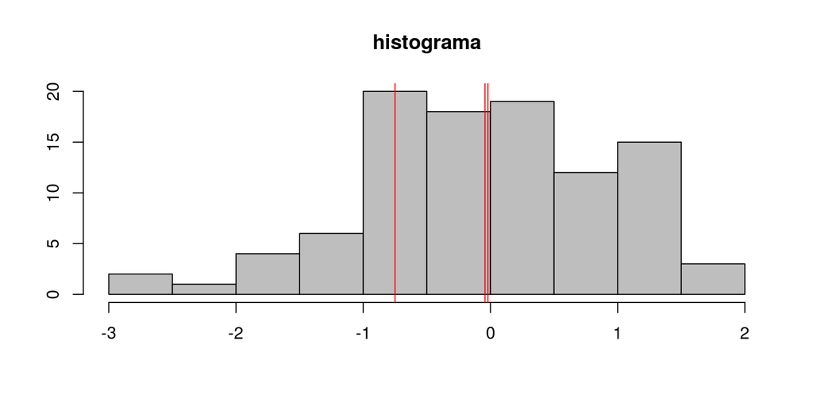

## Gráficamente (normal, muchas obs.)

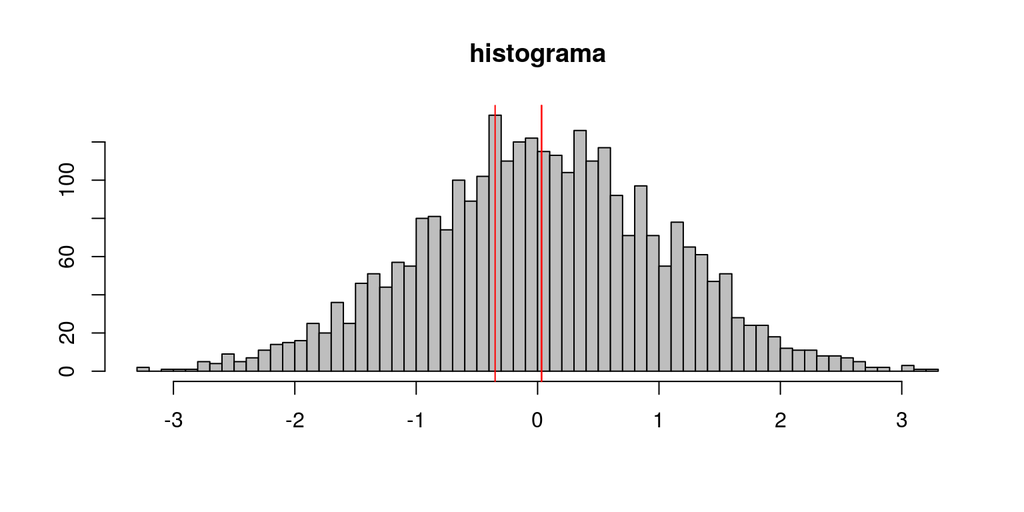

## Gráficamente (gamma, muchas obs.)

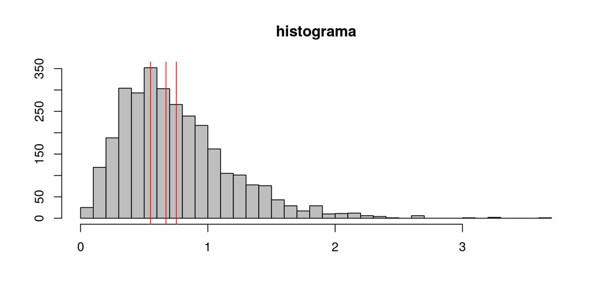

## Gráficamente (lognormal, muchas obs.)

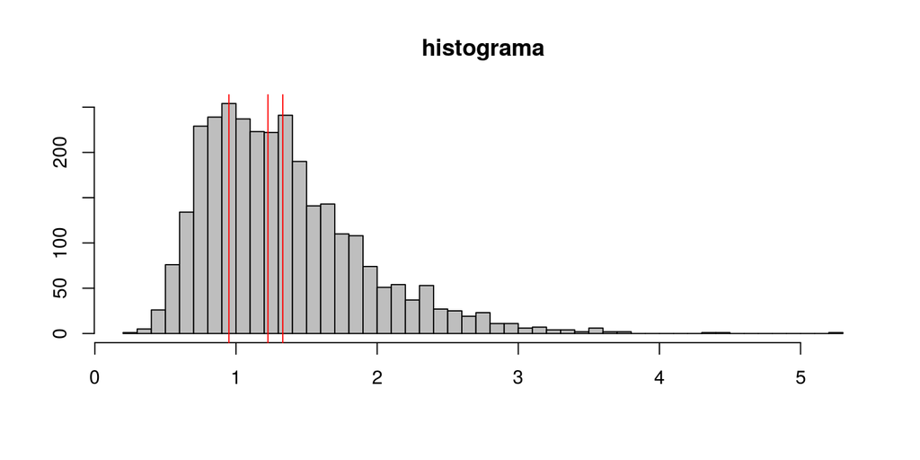

## Salarios medios y medianos

[Vemos qué nos dice el periódico.](http://www.elmundo.es/economia/macroeconomia/2017/06/29/5953ae7222601d5d148b456e.html)

## Problemas de las medidas de centralidad

- No tienen mucho sentido si las observaciones son dispersas
- En tales casos, no representan un *caso típico*
- Eso es particularmente grave en el caso de la media
- Ejercicio: es *representativo* el *ingreso medio* de:
  - ¿Taxistas?
  - ¿Músicos?

## Medidas de dispersión

- No basta con indicar valores centrales
- También hace falta saber si las observaciones están o no lejos de ese valor central
- Medidas habituales de dispersión:
  - Varianza
  - Desviación estándar
  - Cuartiles, deciles, percentiles y cuantiles
  - Otras (p.e., el coeficiente de variación)

## Varianza y desviación estándar

- Son casi la misma cosa (la de es la raíz cuadrada de la varianza)
- Son malos indicadores: casi nadie tiene intuición sobre ellos
- Tienen sentido (prácticamente) solo cuando las distribuciones subyacentes son normales

## Comunicación de la dispersión

- ¿Cómo describirías la distribución de precios de…
  - … los vinos de tu supermercado?
  - … una cámara de fotos?
  - … un portátil?
  - … un coche?
- ¿Usarías el valor medio + desviación estándar?
- Generalmente dirías algo así como: *una botella de vino te puede costar entre 3 y 30 euros*.

## Cuartiles, deciles, percentiles y cuantiles

- Cuartil al 25%: deja por debajo el 25% de las obs. con un valor menor.
- Decil al 40%: deja por debajo el 40% de las obs. con un valor menor.
- Percentil al 99%: solo el 1% de las observaciones están por encima.
- Cuantil al 99.9%: solo el 0.1% de las observaciones están por encima.

> Si tienes el almacén el cuantil 99.9% de los pedidos diarios, solo tendrás una rotura de stock cada tres años (~1000 días)

## Intuiciones sobre cuantiles

- El 50% de las observacione están entre los cuartiles (al 25% y 75%)
- El 99% de las observaciones están entre los cuantiles al 0.5% y 99.5%.
- El 80% de las observaciones están entre los deciles al 10% y 90%.
- Y en la práctica… [¡análisis de sangre!](https://www.murrayhillvethospital.com/wp-content/uploads/2012/09/blood_test_results1.jpg)

# Probabilidades conjuntas, marginales y condicionales

## Lluvias y atascos

Consideramos la siguiente situación:

- En un lugar, el 10% de los días llueve (y el 90% hace sol)
- Cuando llueve, la probabilidad de que haya atascos es del 40%
- Cuando no llueve, la probabilidad de que haya atascos es del 10%

## Gráficamente

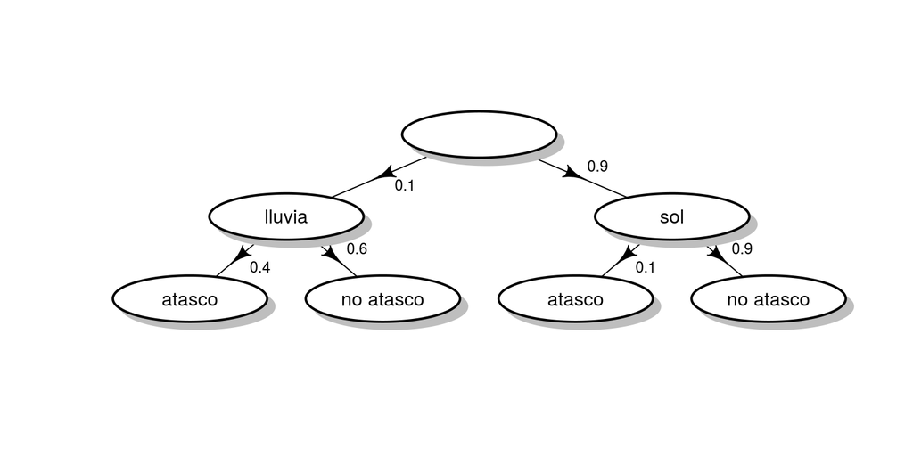

## Probabilidad conjunta

Podemos *tabular* las probabilidades descritas antes:

| tiempo | atasco | prob |
| --- | --- | --- |
| sol | sí | 0.09 |
| sol | no | 0.81 |
| lluvia | sí | 0.04 |
| lluvia | no | 0.06 |

- Esta representación se llama *probabilidad conjunta* (de las variables tiempo y atasco).
- Las probabilidades (columna **prob**) suman 1.
- La hemos construido a partir de las probabilidades marginales (del tiempo) y condicionales (de los atascos condicionados por el tiempo).

## Probabilidades marginales y condicionales

- A *el 10% de los días llueve* se le llama **probabilidad marginal** (luego veremos por qué).
- A *cuando llueve, la probabilidad de que haya atascos es del 40%* se la llama **probabilidad condicional**; se suele escribir así:

$$P(\text{atasco} | \text{lluvia}) = 0.4$$

## Probabilidades conjuntas y marginales

- La tabla de probabilidad conjunta también se puede escribir así:

| P(T,A) | atasco | no atasco |
| --- | --- | --- |
| **lluvia** | 0.04 | 0.06 |
| **sol** | 0.09 | 0.81 |

- Sumando los márgenes, aparecen las **probabilidades marginales**:

[output not shown]

## Probs. conjuntas y condicionales

- Hemos calculado los valores de la tabla de probs. conjuntas, $P(T, A)$ así:
  $$P(T,A) = P(A | T) P(T)$$
- Despejando (y en general),

$$P(A | T) = \frac{P(T,A)}{P(T)}$$

- A partir de las probs. conjuntas y marginales, podemos calcular la condicional.

## Teorema de Bayes

- Si un día hay atasco, ¿cuál es la probabilidad de esté lloviendo?
- De otra manera, ¿podemos calcular $P(T|A)$? Sí:

$$P(T|A) = \frac{P(T,A)}{P(A)} = \frac{P(A|T) P(T)}{P(A)}$$

## Regla de la cadena

- Hemos estudiado un caso con dos variables, $T$ y $A$, y hemos factorizado
  $$P(T,A) = P(A|T) P(T)$$
- En general, si tenemos $A_1, A_2, A_3, A_4$,
  $$P(A_1, A_2, A_3, A_4) = P(A_4|A_1, A_2, A_3) \\ P(A_3|A_1, A_2) P(A_2|A_1)P(A_1)$$
- Demostración: dibuja el grafo correspondiente

## Resumen

- Frecuentemente, las probabilidades asociadas a fenómenos se describen en términos de las **probabilidades marginales** y **condicionales**.
- A partir de ellas podemos calcular las **probabilidades conjuntas**.
- A partir de las probabilidades conjuntas podemos calcular otras probabilidades marginales y condicionales.
- La fórmula de la *inversión* de las probabilidades condicionales se la conoce como **teorema de Bayes**.

# Independencia

## De atascos a monedas

- En el ejemplo previo, los atascos dependían del tiempo
- ¿Pero si no dependiesen de él?
- Un ejemplo clásico: lanzamientos sucesivos de una moneda

## Lanzamientos de monedas

- Si tiramos una moneda al aire, podemos suponer que $P(H) = P(T) = 1/2$.
- ¿Y si la lanzamos al aire dos veces?

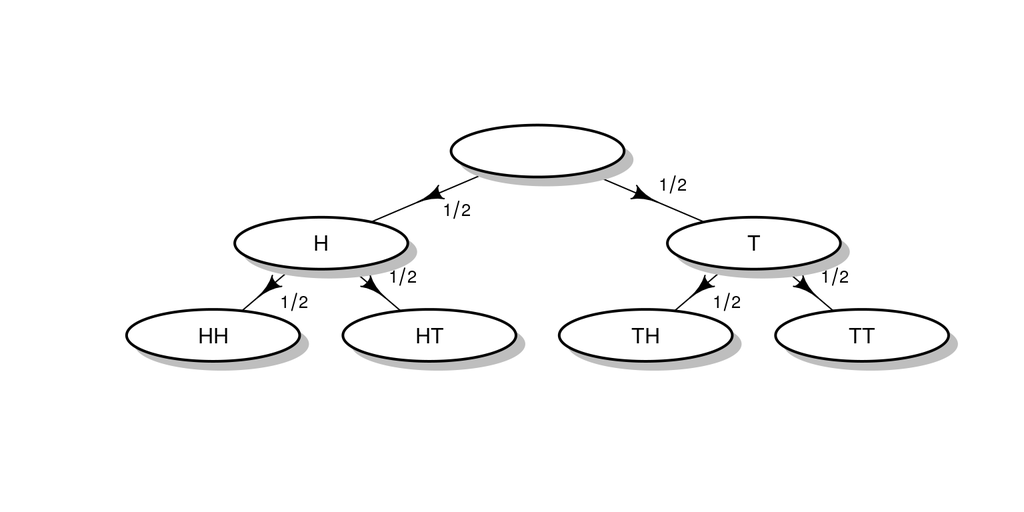

## Independencia y probs. condicionales

- En el ejemplo original, como el tiempo afecta al tráfico, $P(\text{atasco} | \text{lluvia}) \neq P(\text{atasco} | \text{sol})$
- Pero con monedas, $P(H_2 | H_1) = P(H_2|T_1)$:
  - La 2ª tirada no está afectada por la 1ª
  - De hecho, $P(H_2 | H_1) = P(H_2|T_1) = P(H) = 1/2$
- Si $A$y $B$ son independientes, entonces $P(A|B) = P(A)$
- ¡Conocer $B$ no aporta información sobre $A$!

## Independencia y probs. conjuntas

Si A y B son independientes, su prob. conjunta es:

| P(A,B) | b0 | b1 | P(A) |
| --- | --- | --- | --- |
| **a0** | p1 * p3 | p1 * p4 | p1 |
| **a1** | p2 * p3 | p2 * p4 | p2 |
| **P(B)** | p3 | p4 | 1 |

Precisamente porque
$$P(A,B) = P(A|B)P(B) = P(A)P(B)$$

## Independencia y regla de la cadena

- Si $A_1, A_2, A_3, A_4$ son independientes,

$$P(A_1, A_2, A_3, A_4) = P(A_4|A_1, A_2, A_3) \\ P(A_3|A_1, A_2) P(A_2|A_1)P(A_1) = \\
P(A_4) P(A_3) P(A_2)P(A_1)$$

- En el ejemplo de lanzamiento de monedas,
  $$P(HHTHT) = \frac{1}{2^5}$$

## Independencia y ciencia de datos

- Si queremos predecir una variable $Y$ a partir de otras variables $X_1, \dots, X_n$, nos interesa que $X_i \not\perp Y_i$.
- Muchos algoritmos suponen que $y_i \perp y_j$, pero, a menudo, no:
  - Si las $y_i$ son observaciones ordenadas en el tiempo (p.e., temperaturas horarias)
  - Si las $y_i$ se refieren a ubicaciones (se correlacionan con otras $y_j$ próximas)
  - Si bloques de $y_i$ se refieren a un mismo sujeto.

# Distribuciones de probabilidad multivariantes

## Dos variables aleatorias correladas

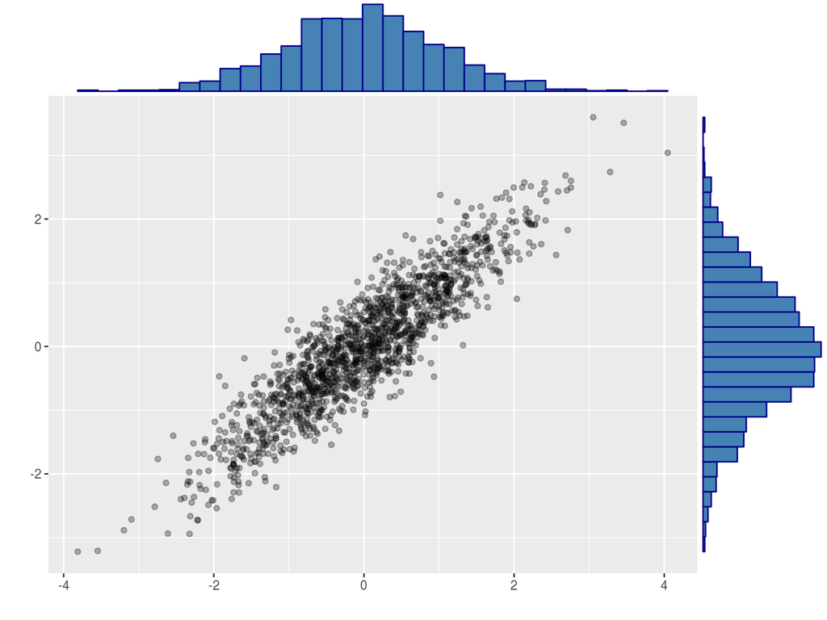

## Dos variables independendientes

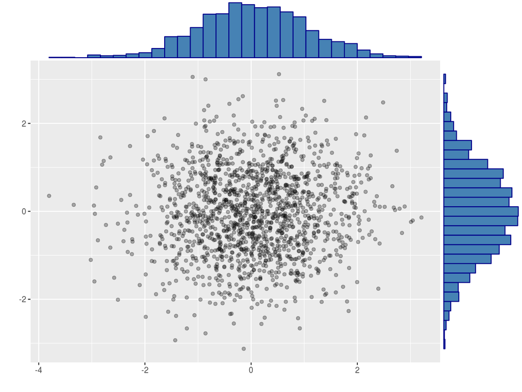

## Covarianza y correlación

$$\sigma(X,Y) = \int (x - E(X)) (y - E(Y)) f(x,y) dx dy$$

- Si $X \perp Y$, entonces $\text{cov(X,Y)} = 0$
- Por definición, $\sigma(X,X) = \sigma^2(X)$
- El coeficiente de **correlación** entre $X$ e $Y$ es

$$\rho(X,Y) = \frac{\sigma(X,Y)}{\sigma(X)\sigma(Y)}$$

# Estadística descriptiva multivariante

## Univariante vs multivariante

- En una sección anterior hemos estudiado cómo visualizar una única variable aleatoria
- Ahora estudiaremos cómo representar 2 (o más) variables aleatorias conjuntamente
- El objetivo será entender la relación entre ambas y mostrarla de la mejor manera posible

## Mondrian

- [Mondrian](http://www.theusrus.de/Mondrian/) es un pequeño programa para la visualización interactiva de datos
- Es (fue) un banco de experimentos para una técnica de análisis estadístico llamada EDA (análisis de datos exploratorios)
- Implementa muchos tipos de visualizaciones, tanto tradicionales como avanzadas
- Permite hacer *linking* y *brushing*

## Análisis de datos exploratorio

- Es un ensayo por construir una estadística cualitativa y visual (en contraposición a la computacional)
- Está basada en el uso interactivo del ordenador
- Su objetivo final es hacer análisis de datos gráfica e interactivamente